# DATA252: Logistic Regression

## Learning Objectives

In this lesson students will learn …

- The generalized linear model (GLM) framework
- How to implement simple and multiple logistic regression
- How to interpret the effect of coefficients in the logistic regression model
- Perform predictions from a logistic regression model
- Trade-offs when choosing a threshold
- Perform variable selection using AIC for glms
- Compare models based on their confusion matrices

## Data Inspiration

Motivation/Background:

- “The Pima Indians of Arizona have the highest reported prevalences of obesity and non-insulin-dependent diabetes mellitus (NIDDM). In parallel with abrupt changes in lifestyle, these prevalences in Arizona Pimas have increased to epidemic proportions during the past decades.” (Ravussin et al. 1994)
- “This study provides compelling evidence that changes in lifestyle associated with Westernization play a major role in the global epidemic of type 2 diabetes.” (Schultz et al. 2006)

Sources:

- https://www.ncbi.nlm.nih.gov/pmc/articles/PMC8943493/
- https://diabetesjournals.org/care/article/17/9/1067/17885/Effects-of-a-Traditional-Lifestyle-on-Obesity-in
- https://diabetesjournals.org/care/article/29/8/1866/28611/Effects-of-Traditional-and-Western-Environments-on

#### Step 1: Import the Data

```r
pima<-read.csv("https://raw.githubusercontent.com/kitadasmalley/DATA252/main/Data/diabetes.csv",
               header=TRUE)

str(pima)
```

```
## 'data.frame':    768 obs. of  9 variables:
##  $ Pregnancies             : int  6 1 8 1 0 5 3 10 2 8 ...
##  $ Glucose                 : int  148 85 183 89 137 116 78 115 197 125 ...
##  $ BloodPressure           : int  72 66 64 66 40 74 50 0 70 96 ...
##  $ SkinThickness           : int  35 29 0 23 35 0 32 0 45 0 ...
##  $ Insulin                 : int  0 0 0 94 168 0 88 0 543 0 ...
##  $ BMI                     : num  33.6 26.6 23.3 28.1 43.1 25.6 31 35.3 30.5 0 ...
##  $ DiabetesPedigreeFunction: num  0.627 0.351 0.672 0.167 2.288 ...
##  $ Age                     : int  50 31 32 21 33 30 26 29 53 54 ...
##  $ Outcome                 : int  1 0 1 0 1 0 1 0 1 1 ...
```

#### Step 2: Visualize

Our goal in this step is to find feature variables that best separates the two groups (0 = diabetes negative; 1 = diabetes positive).

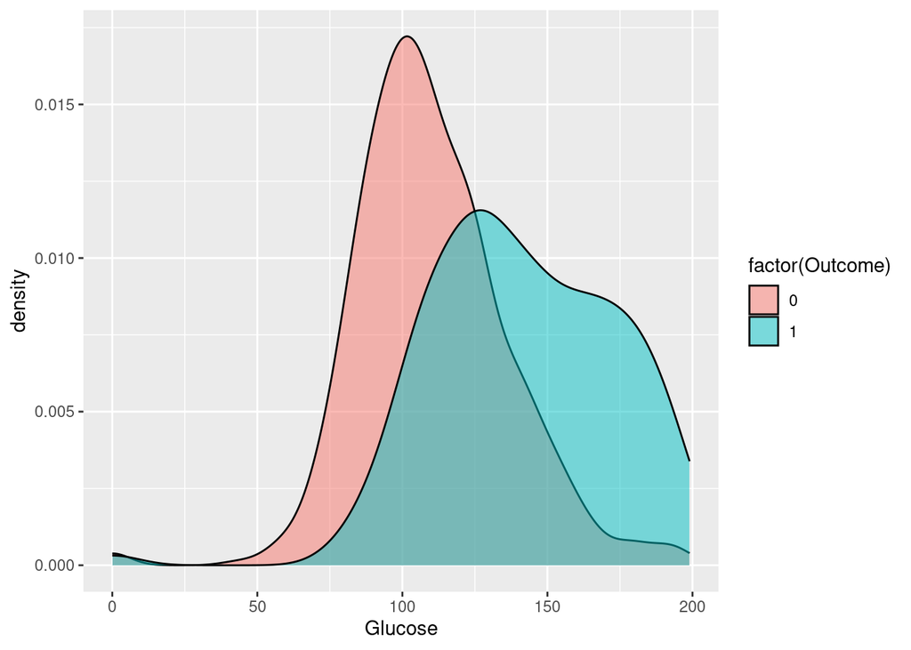

```r
library(tidyverse)

## GLUCOSE DENSITY
ggplot(data=pima, aes(x=Glucose ,fill=factor(Outcome)))+
  geom_density(alpha=.5)
```

#### Step 3: Training and Testing

We will use stratified splitting to create 70/30 - training/testing datasets to build our models.

Note: We will use the same seed as we did for the knn example so that we can compare.

```r
library(caret)
# Split the data into training and test set
set.seed(314)
caretSamp <- createDataPartition(pima$Outcome ,
                                        p = 0.7,
                                        list = FALSE)

## SPLIT TESTING AND TRAINING
trainCaret  <- pima[caretSamp, ]
testCaret <- pima[-caretSamp, ]
```

#### Step 4: Building a Model

“If the only tool you have is a hammer, you tend to see every problem as a nail.” - Abraham Maslow

Linear regression is the most popular model; however, the assumptions are often not met.

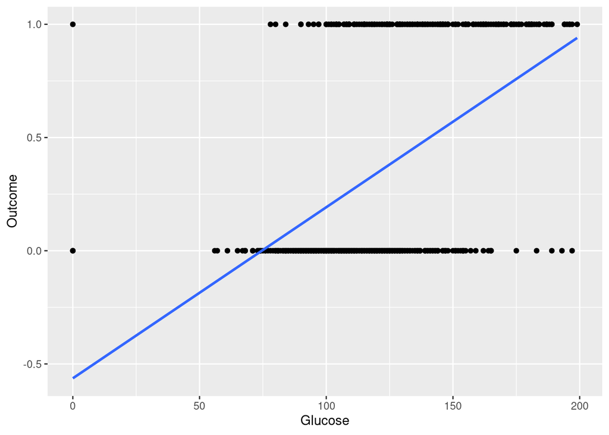

```r
ggplot(data=trainCaret, aes(x=Glucose, y=Outcome))+
  geom_point()+
  geom_smooth(method="lm", se=FALSE)
```

That didn’t work out so well.

So far we’ve covered SLR and MLR, but this only works when we have a continuous response variable. Now let’s extend the model. We can consider the generalized linear model framework.

## Generalized Linear Model (GLM) Framework

A GLM consists of three things:

- A linear predictor
- A distribution of the response
- A link function between the two

Note: In GLM, methods there isn’t a mathematical closed form estimates. We need to use machine learning techniques to optimize and find estimates.

The SLR and MLR models fit within this umbrella framework.

- Model: $Y=\beta_0+\beta_1 X_1+ \cdots+\beta_k X_k+\varepsilon$
  - A linear predictor: $\beta_0+\beta_1 X_1+ \cdots+\beta_k X_k$
  - A distribution of the response: Normal distribution
  - A link function between the two: Identity link

Rather than modeling the response $Y$ directly, model the probability that $Y$ belongs to a category.

- Logistic Model: $logit(p)=log(\frac{p}{1-p})=\beta_0+\beta_1 X_1+ \cdots+\beta_k X_k$
  - A linear predictor: $\beta_0+\beta_1 X_1+ \cdots+\beta_k X_k$
  - A distribution of the response: Binomial distribution
  - A link function between the two: Logit link

## Simple Logistic Regression

As with simple linear regression, a simple logistic regression has only one feature.

$$logit(p)=log(\frac{p}{1-p})=\beta_0+\beta_1
X_1$$

#### Step 5: Simple Logistic Model

Let’s use the feature `Glucose` to predict `Outcome`.

```r
modSimp <- glm(Outcome ~ Glucose, data = trainCaret, family = "binomial")
summary(modSimp)
```

```
##
## Call:
## glm(formula = Outcome ~ Glucose, family = "binomial", data = trainCaret)
##
## Deviance Residuals:
##     Min       1Q   Median       3Q      Max
## -2.2393  -0.7661  -0.5031   0.7952   3.4302
##
## Coefficients:
##              Estimate Std. Error z value Pr(>|z|)
## (Intercept) -5.880463   0.533361  -11.03   <2e-16 ***
## Glucose      0.042146   0.004133   10.20   <2e-16 ***
## ---
## Signif. codes:  0 '***' 0.001 '**' 0.01 '*' 0.05 '.' 0.1 ' ' 1
##
## (Dispersion parameter for binomial family taken to be 1)
##
##     Null deviance: 696.28  on 537  degrees of freedom
## Residual deviance: 548.32  on 536  degrees of freedom
## AIC: 552.32
##
## Number of Fisher Scoring iterations: 4
```

**Definitions**:

- *Deviance* is a metric of the goodness of fit that is used in logistic regression models. This is akin to the sum of squared error in regression.
  - Resources:
    - https://quantifyinghealth.com/deviance-in-logistic-regression/#:~:text=Deviance%20is%20a%20number%20that,ranges%20from%200%20to%20infinity.
    - https://bookdown.org/egarpor/SSS2-UC3M/logreg-deviance.html
- *Fisher Scoring* a numerical algorithm used to estimate maximum likelihood estimates for the $\beta$ coefficients, which do not have a closed form.
  - Resources:
    - https://en.wikipedia.org/wiki/Scoring_algorithm
    - Go to 8:54 https://www.youtube.com/watch?time_continue=539&v=BfKanl1aSG0

Plot the model:

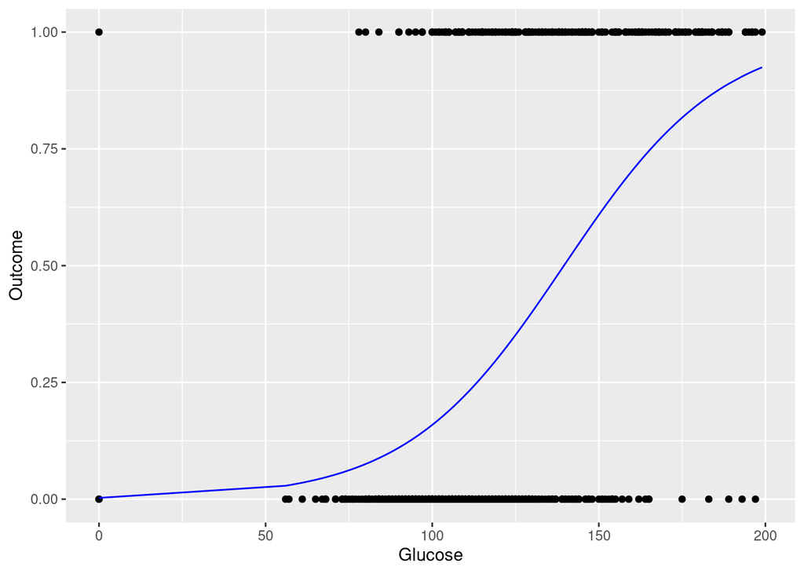

```r
# logistic
ggplot(data=trainCaret, aes(x=Glucose, y=Outcome))+
  geom_point()+
  geom_line(aes(x = Glucose, y = modSimp$fitted), color="blue")
```

#### Step 6: Interpretation

The estimate for the slope, $\beta_1$ is

```r
# slope
slope<-modSimp$coefficients[2]
slope
```

```
##    Glucose
## 0.04214601
```

In SLR a one unit increase in the $X_1$ direction is related to a $\beta_1$ change in the response ($Y$ direction), on average. However, this is more complex in logistic regression. In logistic regression, a one unit increase in the $X_1$ direction is related to a $\beta_1$ change in the *log of the odds*, on average. What does that even mean?

**Definition**:

- *Odds*: $\frac{p}{1-p}$
  - In statistics, odds are an expression of relative probabilities, generally quoted as the odds in favor. The odds (in favor) of an event or a proposition is the ratio of the probability that the event will happen to the probability that the event will not happen.
  - https://en.wikipedia.org/wiki/Odds#:~:text=In%20statistics%2C%20odds%20are%20an,the%20event%20will%20not%20happen

Since we are using the logit link, we will need to back-transform (applying the inverse logit) to interpret the slope.

- $logit(p)=log(\frac{p}{1-p})=\beta_0+\beta_1 (X_1+1)$
- $e^{log(\frac{p}{1-p})}=e^{\beta_0+\beta_1 (X_1+1)}$
- $\frac{p}{1-p}=e^{\beta_0+\beta_1 X_1+\beta_1}$
- $\frac{p}{1-p}=e^{\beta_0+\beta_1 X_1}\times e^{\beta_1}$

The above derivations illustrate that a one unit increase in the $X_1$ direction is related to a odds multiplicative effect on the odds of $e^{\beta_1}$

Thus, the effect of a one unit change in $X_1$ is

```r
# exponentiate
exp(slope)
```

```
##  Glucose
## 1.043047
```

#### Step 7: Prediction

We can use the `predict()` function using the glm model object and the partitioned testing data set.

```r
# PREDICT (DEFAULT)
pred1<-predict(modSimp, newdata = testCaret)
head(pred1)
```

```
##           2           3          10          13          15          18
## -2.29805250  1.83225649 -0.61221209 -0.02216795  1.11577432 -1.37084028
```

##### Question:

- What are your observations of these values?

By default, we the predict function is used it generates the log-odds, we would rather work with the probabilities themselves. Let’s try this code again..

```r
# PREDICT (Response)
pred1R<-predict(modSimp, newdata = testCaret, type="response")
head(pred1R)
```

```
##          2          3         10         13         15         18
## 0.09128438 0.86203032 0.35155475 0.49445824 0.75320406 0.20248412
```

#### Step 8: Thresholding and Confusion Matrix

This method produces estimated probabilities of observing a success (1), therefore, we will need to set a threshold to create a binary prediction. A natural first choice might be to use 0.50 as a threshold. This implies that errors (false positives and false negatives) have equal weight.

```r
## CONFUSION MATRIX
conf_mat1<-data.frame(testOutcome=testCaret$Outcome, predOut=pred1R>.5)
table(conf_mat1$predOut, conf_mat1$testOutcome)
```

```
##
##           0   1
##   FALSE 128  42
##   TRUE   22  38
```

```r
## CORRECT RATE
mean(conf_mat1$predOut==conf_mat1$testOutcome)
```

```
## [1] 0.7217391
```

```r
## CONFUSION MATRIX
conf_mat2<-data.frame(testOutcome=testCaret$Outcome, predOut=pred1R>.3)
table(conf_mat2$predOut, conf_mat2$testOutcome)
```

```
##
##          0  1
##   FALSE 99 22
##   TRUE  51 58
```

```r
## CORRECT RATE
mean(conf_mat2$predOut==conf_mat2$testOutcome)
```

```
## [1] 0.6826087
```

##### Question:

- What would you set the threshold to to have no false positives? What would be the cost of this? (in terms of error)
- What would you set the threshold to to have no false negatives? What would be the cost of this? (in terms of error)

## Multiple Logistic Regression

In multiple logistic regression we consider more features!

$$logit(p)=log(\frac{p}{1-p})=\beta_0+\beta_1
X_1+\beta_2 X_2+\cdots+\beta_k X_k$$

#### Step 9: Visualize

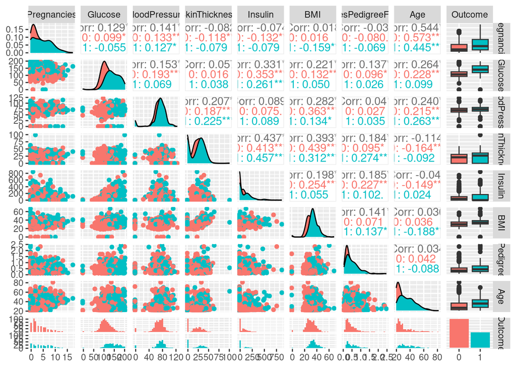

```r
library(GGally)
library(tidyverse)
pima$Outcome<-as.factor(pima$Outcome)

ggpairs(pima,
        ggplot2::aes(color=factor(Outcome)))
```

#### Step 10: Fit a Saturated Model

```r
modMulti<-glm(Outcome ~.,
          data = trainCaret, family = "binomial")

summary(modMulti)
```

```
##
## Call:
## glm(formula = Outcome ~ ., family = "binomial", data = trainCaret)
##
## Deviance Residuals:
##     Min       1Q   Median       3Q      Max
## -2.7295  -0.6871  -0.3715   0.6500   2.8935
##
## Coefficients:
##                           Estimate Std. Error z value Pr(>|z|)
## (Intercept)              -9.864678   0.955914 -10.320  < 2e-16 ***
## Pregnancies               0.089298   0.039861   2.240  0.02507 *
## Glucose                   0.039068   0.004743   8.238  < 2e-16 ***
## BloodPressure            -0.010305   0.006199  -1.662  0.09645 .
## SkinThickness            -0.001639   0.008613  -0.190  0.84904
## Insulin                  -0.001380   0.001071  -1.288  0.19760
## BMI                       0.101616   0.019038   5.338 9.42e-08 ***
## DiabetesPedigreeFunction  0.827195   0.374813   2.207  0.02732 *
## Age                       0.033207   0.012437   2.670  0.00759 **
## ---
## Signif. codes:  0 '***' 0.001 '**' 0.01 '*' 0.05 '.' 0.1 ' ' 1
##
## (Dispersion parameter for binomial family taken to be 1)
##
##     Null deviance: 696.28  on 537  degrees of freedom
## Residual deviance: 479.07  on 529  degrees of freedom
## AIC: 497.07
##
## Number of Fisher Scoring iterations: 5
```

##### Question:

- Is the effect of Pregnancies significant at an $\alpha=0.05$ level?
- What is the effect of one additional Pregnancy on the odds of having diabetes?

#### Step 11: Variable Selection

If we want to perform stepwise selection for a binary response we will need to use the `bestglm` package. This package will perform stepwise selection by minimizing the AIC.

```r
#install.packages("bestglm")
library(bestglm)
```

##### Backward Selection

Backward selection is the default of the `step()` function. Observe that the algorithm starts with all the variables, then removes `SkinThickness`, and then stops because it has minimized the AIC.

```r
## Backward
step(modMulti)
```

```
## Start:  AIC=497.07
## Outcome ~ Pregnancies + Glucose + BloodPressure + SkinThickness +
##     Insulin + BMI + DiabetesPedigreeFunction + Age
##
##                            Df Deviance    AIC
## - SkinThickness             1   479.11 495.11
## - Insulin                   1   480.72 496.72
## <none>                          479.07 497.07
## - BloodPressure             1   481.87 497.87
## - DiabetesPedigreeFunction  1   484.14 500.14
## - Pregnancies               1   484.17 500.17
## - Age                       1   486.20 502.20
## - BMI                       1   512.94 528.94
## - Glucose                   1   567.47 583.47
##
## Step:  AIC=495.11
## Outcome ~ Pregnancies + Glucose + BloodPressure + Insulin + BMI +
##     DiabetesPedigreeFunction + Age
##
##                            Df Deviance    AIC
## <none>                          479.11 495.11
## - Insulin                   1   481.37 495.37
## - BloodPressure             1   482.11 496.11
## - DiabetesPedigreeFunction  1   484.15 498.15
## - Pregnancies               1   484.20 498.20
## - Age                       1   486.34 500.34
## - BMI                       1   516.57 530.57
## - Glucose                   1   570.95 584.95
```

```
##
## Call:  glm(formula = Outcome ~ Pregnancies + Glucose + BloodPressure +
##     Insulin + BMI + DiabetesPedigreeFunction + Age, family = "binomial",
##     data = trainCaret)
##
## Coefficients:
##              (Intercept)               Pregnancies                   Glucose
##                -9.858443                  0.089295                  0.039208
##            BloodPressure                   Insulin                       BMI
##                -0.010512                 -0.001465                  0.100440
## DiabetesPedigreeFunction                       Age
##                 0.818040                  0.033384
##
## Degrees of Freedom: 537 Total (i.e. Null);  530 Residual
## Null Deviance:       696.3
## Residual Deviance: 479.1     AIC: 495.1
```

##### Forward Selection

We can perform forward selection by specifying the full model and the null model. This algorithm works by adding one variable in at a time and then stops when the AIC is minimized.

```r
## NULL MODEL
mod0 <- glm(Outcome ~ 1, family = binomial, data = trainCaret)

## FORWARD Selection
step(mod0, scope = list(upper = modMulti, lower = mod0),
     method = "forward")
```

```
## Start:  AIC=698.28
## Outcome ~ 1
##
##                            Df Deviance    AIC
## + Glucose                   1   548.32 552.32
## + BMI                       1   634.08 638.08
## + Age                       1   651.92 655.92
## + Pregnancies               1   667.54 671.54
## + DiabetesPedigreeFunction  1   680.46 684.46
## + Insulin                   1   684.13 688.13
## + SkinThickness             1   691.52 695.52
## + BloodPressure             1   693.41 697.41
## <none>                          696.28 698.28
##
## Step:  AIC=552.32
## Outcome ~ Glucose
##
##                            Df Deviance    AIC
## + BMI                       1   515.34 521.34
## + Pregnancies               1   529.41 535.41
## + Age                       1   529.85 535.85
## + DiabetesPedigreeFunction  1   542.29 548.29
## <none>                          548.32 552.32
## + SkinThickness             1   546.93 552.93
## + Insulin                   1   546.99 552.99
## + BloodPressure             1   548.30 554.30
## - Glucose                   1   696.28 698.28
##
## Step:  AIC=521.34
## Outcome ~ Glucose + BMI
##
##                            Df Deviance    AIC
## + Age                       1   493.66 501.66
## + Pregnancies               1   496.12 504.12
## + DiabetesPedigreeFunction  1   511.20 519.20
## + Insulin                   1   511.86 519.86
## <none>                          515.34 521.34
## + SkinThickness             1   513.92 521.92
## + BloodPressure             1   514.67 522.67
## - BMI                       1   548.32 552.32
```

[output cut: 58 more lines]

```
##
## Step:  AIC=495.11
## Outcome ~ Glucose + BMI + Age + Pregnancies + DiabetesPedigreeFunction +
##     BloodPressure + Insulin
##
##                            Df Deviance    AIC
## <none>                          479.11 495.11
## - Insulin                   1   481.37 495.37
## - BloodPressure             1   482.11 496.11
## + SkinThickness             1   479.07 497.07
## - DiabetesPedigreeFunction  1   484.15 498.15
## - Pregnancies               1   484.20 498.20
## - Age                       1   486.34 500.34
## - BMI                       1   516.57 530.57
## - Glucose                   1   570.95 584.95
```

```
##
## Call:  glm(formula = Outcome ~ Glucose + BMI + Age + Pregnancies + DiabetesPedigreeFunction +
##     BloodPressure + Insulin, family = binomial, data = trainCaret)
##
## Coefficients:
##              (Intercept)                   Glucose                       BMI
##                -9.858443                  0.039208                  0.100440
##                      Age               Pregnancies  DiabetesPedigreeFunction
##                 0.033384                  0.089295                  0.818040
##            BloodPressure                   Insulin
##                -0.010512                 -0.001465
##
## Degrees of Freedom: 537 Total (i.e. Null);  530 Residual
## Null Deviance:       696.3
## Residual Deviance: 479.1     AIC: 495.1
```

##### Best Subset Selection

Choose the best model of a given size.

```r
# the Xy matrix needs y as the right-most variable
# this one already has Outcome at the last column
best.Xy <- trainCaret

# Run best subset
bglm.AIC = bestglm(Xy = best.Xy, family = binomial, IC = "AIC",
                   TopModels = 10)
```

```
## Morgan-Tatar search since family is non-gaussian.
```

```r
bglm.AIC$BestModels
```

```
##    Pregnancies Glucose BloodPressure SkinThickness Insulin  BMI
## 1         TRUE    TRUE          TRUE         FALSE    TRUE TRUE
## 2         TRUE    TRUE          TRUE         FALSE   FALSE TRUE
## 3         TRUE    TRUE         FALSE         FALSE    TRUE TRUE
## 4         TRUE    TRUE          TRUE          TRUE   FALSE TRUE
## 5         TRUE    TRUE         FALSE         FALSE   FALSE TRUE
## 6         TRUE    TRUE          TRUE          TRUE    TRUE TRUE
## 7         TRUE    TRUE         FALSE          TRUE   FALSE TRUE
## 8         TRUE    TRUE          TRUE         FALSE   FALSE TRUE
## 9         TRUE    TRUE         FALSE          TRUE    TRUE TRUE
## 10        TRUE    TRUE          TRUE         FALSE    TRUE TRUE
##    DiabetesPedigreeFunction  Age Criterion
## 1                      TRUE TRUE  493.1085
## 2                      TRUE TRUE  493.3689
## 3                      TRUE TRUE  494.1125
## 4                      TRUE TRUE  494.7150
## 5                      TRUE TRUE  494.8003
## 6                      TRUE TRUE  495.0723
## 7                      TRUE TRUE  495.4712
## 8                     FALSE TRUE  495.6468
## 9                      TRUE TRUE  495.8685
## 10                    FALSE TRUE  496.1452
```

#### Step 12: Best Model

Observe that the **best** model is agreed upon by the backward, forward, and best subset methods!

```r
## BEST MODEL INCLUDES:
## Pregnancies+Glucose+BloodPressure+Insulin+BMI+DiabetesPedigreeFunction+Age
modBest<-glm(Outcome ~Pregnancies+Glucose+BloodPressure+
            Insulin+BMI+DiabetesPedigreeFunction+Age,
          data = trainCaret, family = "binomial")

summary(modBest)
```

```
##
## Call:
## glm(formula = Outcome ~ Pregnancies + Glucose + BloodPressure +
##     Insulin + BMI + DiabetesPedigreeFunction + Age, family = "binomial",
##     data = trainCaret)
##
## Deviance Residuals:
##     Min       1Q   Median       3Q      Max
## -2.7148  -0.6859  -0.3728   0.6465   2.8887
##
## Coefficients:
##                            Estimate Std. Error z value Pr(>|z|)
## (Intercept)              -9.8584426  0.9550310 -10.323  < 2e-16 ***
## Pregnancies               0.0892952  0.0398994   2.238  0.02522 *
## Glucose                   0.0392085  0.0046882   8.363  < 2e-16 ***
## BloodPressure            -0.0105119  0.0061027  -1.723  0.08498 .
## Insulin                  -0.0014653  0.0009707  -1.510  0.13114
## BMI                       0.1004396  0.0179787   5.587 2.32e-08 ***
## DiabetesPedigreeFunction  0.8180399  0.3714597   2.202  0.02765 *
## Age                       0.0333838  0.0124085   2.690  0.00714 **
## ---
## Signif. codes:  0 '***' 0.001 '**' 0.01 '*' 0.05 '.' 0.1 ' ' 1
##
## (Dispersion parameter for binomial family taken to be 1)
##
##     Null deviance: 696.28  on 537  degrees of freedom
## Residual deviance: 479.11  on 530  degrees of freedom
## AIC: 495.11
##
## Number of Fisher Scoring iterations: 5
```

Predict for the best model:

```r
## Predict
predBest<-predict(modBest, newdata = testCaret, type="response")
```

Threshold and Confusion Matrix:

```r
## Threshold
conf_matBest<-data.frame(testOutcome=testCaret$Outcome, predOut=predBest>.5)

## Confusion Matrix
table(conf_matBest$predOut, conf_matBest$testOutcome)
```

```
##
##           0   1
##   FALSE 126  36
##   TRUE   24  44
```

```r
## CORRECT RATE
mean(conf_matBest$predOut==conf_matBest$testOutcome)
```

```
## [1] 0.7391304
```

#### Step 13: Compare Models

Using the same training and testing sets, we can compare the error rates. Which model would you pick?

##### A. Simple Logistic

Only uses `Glucose` to predict `Outcome`.

```r
## Confusion Matrix
table(conf_mat1$predOut, conf_mat1$testOutcome)
```

```
##
##           0   1
##   FALSE 128  42
##   TRUE   22  38
```

```r
## CORRECT RATE
mean(conf_mat1$predOut==conf_mat1$testOutcome)
```

```
## [1] 0.7217391
```

##### B. Best Multiple Logistic

Uses `Pregnancies`, `Glucose`, `BloodPressure`, `Insulin`, `BMI`, `DiabetesPedigreeFunction`, and `Age` to predict `Outcome`.

```r
## Confusion Matrix
table(conf_matBest$predOut, conf_matBest$testOutcome)
```

```
##
##           0   1
##   FALSE 126  36
##   TRUE   24  44
```

```r
## CORRECT RATE
mean(conf_matBest$predOut==conf_matBest$testOutcome)
```

```
## [1] 0.7391304
```

##### C. KNN

Uses the 12 closest neighbors.

From the KNN lesson we had

```r
## Confusion Matrix
table(knn.pred12,testOut)
```

```
##           testOut
## knn.pred12   0   1
##          0 118  37
##          1  32  43
```

```r
## CORRECT RATE
mean(knn.pred12==testOut)
```

```
## [1] 0.7
```